# PTT文字雲_爐石版

### 2018-07-12

## 爬蟲程式

```r
library(xml2)
library(tmcn)
library(rvest)
pttTestFunction <- function(URL, filename)
{
  #URL   = "https://www.ptt.cc/bbs/NTUcourse/index.html"
  html  = read_html(URL)
  title = html_nodes(html, "a")
  href  = html_attr(title, "href")
  data = data.frame(title = toUTF8(html_text(title)),
                    href = href)
  data = data[-c(1:10),]
  getContent <- function(x) {
    url  = paste0("https://www.ptt.cc", x)
    tag  = html_node(read_html(url), 'div#main-content.bbs-screen.bbs-content')
    text = toUTF8(html_text(tag))
  }
  #getContent(data$href[1])
  allText = sapply(data$href, getContent)
  allText
  #out <- file(filename, "w", encoding="BIG-5")
  write.table(allText, filename)
  #close(out)
}
```

## 爬蟲程序

```r
id = c(1:10)
URL = paste0("https://www.ptt.cc/bbs/Hearthstone/index", id, ".html")
filename = paste0(id, ".txt")
pttTestFunction(URL[1], filename[1])
mapply(pttTestFunction,
       URL = URL, filename = filename)
```

```
## $`https://www.ptt.cc/bbs/Hearthstone/index1.html`
## NULL
##
## $`https://www.ptt.cc/bbs/Hearthstone/index2.html`
## NULL
##
## $`https://www.ptt.cc/bbs/Hearthstone/index3.html`
## NULL
##
## $`https://www.ptt.cc/bbs/Hearthstone/index4.html`
## NULL
##
## $`https://www.ptt.cc/bbs/Hearthstone/index5.html`
## NULL
##
## $`https://www.ptt.cc/bbs/Hearthstone/index6.html`
## NULL
##
## $`https://www.ptt.cc/bbs/Hearthstone/index7.html`
## NULL
##
## $`https://www.ptt.cc/bbs/Hearthstone/index8.html`
## NULL
##
## $`https://www.ptt.cc/bbs/Hearthstone/index9.html`
## NULL
##
## $`https://www.ptt.cc/bbs/Hearthstone/index10.html`
## NULL
```

## 文本清理

```r
rm(list=ls(all.names = TRUE))
library(NLP)
library(tm)
library(jiebaRD)
library(jiebaR)
library(RColorBrewer)
library(wordcloud)
filenames <- list.files(getwd(), pattern="*.txt")
files <- lapply(filenames, readLines)
docs <- Corpus(VectorSource(files))
#移除可能有問題的符號
toSpace <- content_transformer(function(x, pattern) {
  return (gsub(pattern, " ", x))
}
)
docs <- tm_map(docs, toSpace, "※")
docs <- tm_map(docs, toSpace, "◆")
docs <- tm_map(docs, toSpace, "‧")
docs <- tm_map(docs, toSpace, "的")
docs <- tm_map(docs, toSpace, "我")
docs <- tm_map(docs, toSpace, "是")
docs <- tm_map(docs, toSpace, "看板")
docs <- tm_map(docs, toSpace, "作者")
docs <- tm_map(docs, toSpace, "發信站")
docs <- tm_map(docs, toSpace, "批踢踢實業坊")
docs <- tm_map(docs, toSpace, "[a-zA-Z]")
docs <- tm_map(docs, toSpace, "推")
docs <- tm_map(docs, toSpace, "標題")
docs <- tm_map(docs, toSpace, "時間")
docs <- tm_map(docs, toSpace, "開版")
docs <- tm_map(docs, toSpace, "了")
docs <- tm_map(docs, toSpace, "在")
docs <- tm_map(docs, toSpace, "防守")
docs <- tm_map(docs, toSpace, "就")
docs <- tm_map(docs, toSpace, "不")
docs <- tm_map(docs, toSpace, "有")
docs <- tm_map(docs, toSpace, "不")
docs <- tm_map(docs, toSpace, "他")
docs <- tm_map(docs, toSpace, "恭喜")
docs <- tm_map(docs, toSpace, "玩")
docs <- tm_map(docs, toSpace, "閒聊")
docs <- tm_map(docs, toSpace, "文")
docs <- tm_map(docs, toSpace, "遊戲")
docs <- tm_map(docs, toSpace, "文章")
docs <- tm_map(docs, toSpace, "等")
docs <- tm_map(docs, toSpace, "討論")
docs <- tm_map(docs, toSpace, "開板")
docs <- tm_map(docs, toSpace, "戰記")
docs <- tm_map(docs, toSpace, "大家")
docs <- tm_map(docs, toSpace, "分享")
docs <- tm_map(docs, toSpace, "噓")
docs <- tm_map(docs, toSpace, "都")
docs <- tm_map(docs, toSpace, "警告")
docs <- tm_map(docs, toSpace, "水桶")
docs <- tm_map(docs, toSpace, "目前")
docs <- tm_map(docs, toSpace, "連署")
docs <- tm_map(docs, toSpace, "到此一遊")
docs <- tm_map(docs, toSpace, "人")
docs <- tm_map(docs, toSpace, "請")
docs <- tm_map(docs, toSpace, "阿")
docs <- tm_map(docs, toSpace, "要")
docs <- tm_map(docs, toSpace, "章")
docs <- tm_map(docs, toSpace, "會")
docs <- tm_map(docs, toSpace, "之")
docs <- tm_map(docs, toSpace, "中")
docs <- tm_map(docs, toSpace, "喔")
docs <- tm_map(docs, toSpace, "以為")
docs <- tm_map(docs, toSpace, "如果")
docs <- tm_map(docs, toSpace, "板規")
docs <- tm_map(docs, toSpace, "最近")
docs <- tm_map(docs, toSpace, "這個")
docs <- tm_map(docs, toSpace, "一些")
docs <- tm_map(docs, toSpace, "啊")
docs <- tm_map(docs, toSpace, "能")
docs <- tm_map(docs, toSpace, "可")
docs <- tm_map(docs, toSpace, "還")
docs <- tm_map(docs, toSpace, "車車")
docs <- tm_map(docs, toSpace, "希望")
docs <- tm_map(docs, toSpace, "沒")
docs <- tm_map(docs, toSpace, "看")
docs <- tm_map(docs, toSpace, "很")
docs <- tm_map(docs, toSpace, "過")
docs <- tm_map(docs, toSpace, "這")
docs <- tm_map(docs, toSpace, "打")
docs <- tm_map(docs, toSpace, "想")
docs <- tm_map(docs, toSpace, "才")
docs <- tm_map(docs, toSpace, "及")
docs <- tm_map(docs, toSpace, "到")
docs <- tm_map(docs, toSpace, "好")
docs <- tm_map(docs, toSpace, "你")
docs <- tm_map(docs, toSpace, "也")
docs <- tm_map(docs, toSpace, "以")
docs <- tm_map(docs, toSpace, "用")
docs <- tm_map(docs, toSpace, "嗎")
docs <- tm_map(docs, toSpace, "只")
docs <- tm_map(docs, toSpace, "牌")
docs <- tm_map(docs, toSpace, "多")
docs <- tm_map(docs, toSpace, "所")
docs <- tm_map(docs, toSpace, "一個")
docs <- tm_map(docs, toSpace, "被")
docs <- tm_map(docs, toSpace, "卡")
docs <- tm_map(docs, toSpace, "後")
docs <- tm_map(docs, toSpace, "跟")
docs <- tm_map(docs, toSpace, "吧")
docs <- tm_map(docs, toSpace, "但")
docs <- tm_map(docs, toSpace, "包")
docs <- tm_map(docs, toSpace, "幹")
docs <- tm_map(docs, toSpace, "對手")
docs <- tm_map(docs, toSpace, "問題")
docs <- tm_map(docs, toSpace, "自已")
docs <- tm_map(docs, toSpace, "職業")
docs <- tm_map(docs, toSpace, " 知道")
docs <- tm_map(docs, toSpace, "開始")
docs <- tm_map(docs, toSpace, "回合")
docs <- tm_map(docs, toSpace, "編輯")
docs <- tm_map(docs, toSpace, "一張")
docs <- tm_map(docs, toSpace, "啦")
docs <- tm_map(docs, toSpace, "又")
docs <- tm_map(docs, toSpace, "去")
docs <- tm_map(docs, toSpace, "把")
docs <- tm_map(docs, toSpace, "讓")
docs <- tm_map(docs, toSpace, "對")
docs <- tm_map(docs, toSpace, "們")
docs <- tm_map(docs, toSpace, "說")
docs <- tm_map(docs, toSpace, "現")
docs <- tm_map(docs, toSpace, "其")
docs <- tm_map(docs, toSpace, "爐石")
docs <- tm_map(docs, toSpace, "家")
docs <- tm_map(docs, toSpace, "給")
docs <- tm_map(docs, toSpace, "一直")
docs <- tm_map(docs, toSpace, "來自")
docs <- tm_map(docs, toSpace, "英雄")
docs <- tm_map(docs, toSpace, "真")
docs <- tm_map(docs, toSpace, "出來")
docs <- tm_map(docs, toSpace, "今天")
docs <- tm_map(docs, toSpace, "結果")
docs <- tm_map(docs, toSpace, "直接")
docs <- tm_map(docs, toSpace, "得")
docs <- tm_map(docs, toSpace, "比較")
docs <- tm_map(docs, toSpace, "覺得")
docs <- tm_map(docs, toSpace, "什麼")
docs <- tm_map(docs, toSpace, "自己")
docs <- tm_map(docs, toSpace, "為")
docs <- tm_map(docs, toSpace, "出")
docs <- tm_map(docs, toSpace, "問")
docs <- tm_map(docs, toSpace, "片")
docs <- tm_map(docs, toSpace, "像")
docs <- tm_map(docs, toSpace, "開")
docs <- tm_map(docs, toSpace, "最")
docs <- tm_map(docs, toSpace, "或")
docs <- tm_map(docs, toSpace, "下")
docs <- tm_map(docs, toSpace, "大")
docs <- tm_map(docs, toSpace, "一")
docs <- tm_map(docs, toSpace, "張")
docs <- tm_map(docs, toSpace, "什麼")
docs <- tm_map(docs, toSpace, "組")
docs <- tm_map(docs, toSpace, "點")
docs <- tm_map(docs, toSpace, "抽")
docs <- tm_map(docs, toSpace, "上")
docs <- tm_map(docs, toSpace, "樣")
docs <- tm_map(docs, toSpace, "遇")
docs <- tm_map(docs, toSpace, "拿")
docs <- tm_map(docs, toSpace, "因")
docs <- tm_map(docs, toSpace, "然")
docs <- tm_map(docs, toSpace, "手")
docs <- tm_map(docs, toSpace, "次")
docs <- tm_map(docs, toSpace, "應該")
docs <- tm_map(docs, toSpace, "感覺")
docs <- tm_map(docs, toSpace, "樓上")
docs <- tm_map(docs, toSpace, "發")
docs <- tm_map(docs, toSpace, "第")
docs <- tm_map(docs, toSpace, "面")
docs <- tm_map(docs, toSpace, "收")
docs <- tm_map(docs, toSpace, "帳號")
docs <- tm_map(docs, toSpace, "怎麼")
docs <- tm_map(docs, toSpace, "斷線")
docs <- tm_map(docs, toSpace, "死")
docs <- tm_map(docs, toSpace, "時候")
docs <- tm_map(docs, toSpace, "新")
docs <- tm_map(docs, toSpace, "前")
docs <- tm_map(docs, toSpace, "基本")
docs <- tm_map(docs, toSpace, "序號")
docs <- tm_map(docs, toSpace, "傷害")
docs <- tm_map(docs, toSpace, "傳")
docs <- tm_map(docs, toSpace, "覺")
docs <- tm_map(docs, toSpace, "三")
docs <- tm_map(docs, toSpace, "放")
docs <- tm_map(docs, toSpace, "方")
docs <- tm_map(docs, toSpace, "使")
docs <- tm_map(docs, toSpace, "再")
docs <- tm_map(docs, toSpace, "時")
docs <- tm_map(docs, toSpace, "那")
docs <- tm_map(docs, toSpace, "太")
docs <- tm_map(docs, toSpace, "和")
docs <- tm_map(docs, toSpace, "贏")
docs <- tm_map(docs, toSpace, "先")
docs <- tm_map(docs, toSpace, "來")
docs <- tm_map(docs, toSpace, "個")
docs <- tm_map(docs, toSpace, "朋友")
docs <- tm_map(docs, toSpace, "根本")
docs <- tm_map(docs, toSpace, "垃圾")
docs <- tm_map(docs, toSpace, "算")
docs <- tm_map(docs, toSpace, "隻")
docs <- tm_map(docs, toSpace, "更")
docs <- tm_map(docs, toSpace, "力")
docs <- tm_map(docs, toSpace, "完")
docs <- tm_map(docs, toSpace, "當")
docs <- tm_map(docs, toSpace, "選")
docs <- tm_map(docs, toSpace, "重")
docs <- tm_map(docs, toSpace, "同")
docs <- tm_map(docs, toSpace, "種")
docs <- tm_map(docs, toSpace, "話")
docs <- tm_map(docs, toSpace, "兩")
docs <- tm_map(docs, toSpace, "剛")
docs <- tm_map(docs, toSpace, "每")
docs <- tm_map(docs, toSpace, "日")
docs <- tm_map(docs, toSpace, "改")
docs <- tm_map(docs, toSpace, "回")
docs <- tm_map(docs, toSpace, "全")
docs <- tm_map(docs, toSpace, "成")
docs <- tm_map(docs, toSpace, "強")
docs <- tm_map(docs, toSpace, "攻擊")
docs <- tm_map(docs, toSpace, "於")
docs <- tm_map(docs, toSpace, "小")
docs <- tm_map(docs, toSpace, "機")
docs <- tm_map(docs, toSpace, "效果")
docs <- tm_map(docs, toSpace, "勝")
docs <- tm_map(docs, toSpace, "加")
docs <- tm_map(docs, toSpace, "天")
docs <- tm_map(docs, toSpace, "些")
docs <- tm_map(docs, toSpace, "掉")
docs <- tm_map(docs, toSpace, "做")
docs <- tm_map(docs, toSpace, "錯")
docs <- tm_map(docs, toSpace, "嗎")
docs <- tm_map(docs, toSpace, "少")
docs <- tm_map(docs, toSpace, "樓")
docs <- tm_map(docs, toSpace, "者")
docs <- tm_map(docs, toSpace, "已經")
docs <- tm_map(docs, toSpace, "與")
docs <- tm_map(docs, toSpace, "活動")
docs <- tm_map(docs, toSpace, "起")
docs <- tm_map(docs, toSpace, "送")
docs <- tm_map(docs, toSpace, "買")
docs <- tm_map(docs, toSpace, "需")
docs <- tm_map(docs, toSpace, "定")
docs <- tm_map(docs, toSpace, "金")
docs <- tm_map(docs, toSpace, "主")
docs <- tm_map(docs, toSpace, "模式")
docs <- tm_map(docs, toSpace, "而爽")
docs <- tm_map(docs, toSpace, "超")
docs <- tm_map(docs, toSpace, "昨天")
docs <- tm_map(docs, toSpace, "換")
docs <- tm_map(docs, toSpace, "高")
docs <- tm_map(docs, toSpace, "輸")
docs <- tm_map(docs, toSpace, "定")
docs <- tm_map(docs, toSpace, "送")
docs <- tm_map(docs, toSpace, "期")
docs <- tm_map(docs, toSpace, "起")
#移除標點符號 (punctuation)
#移除數字 (digits)、空白 (white space)
docs <- tm_map(docs, removePunctuation)
docs <- tm_map(docs, removeNumbers)
docs <- tm_map(docs, stripWhitespace)
```

## 詞頻矩陣

```r
mixseg = worker()
jieba_tokenizer=function(d){
  unlist(segment(d[[1]],mixseg))
}
seg = lapply(docs, jieba_tokenizer)
freqFrame = as.data.frame(table(unlist(seg)))
freqFrame = freqFrame[order(freqFrame$Freq,decreasing=TRUE), ]
library(knitr)
kable(head(freqFrame), format = "markdown")
```

|  | Var1 | Freq |
| --- | --- | --- |
| 5149 | 競技場 | 276 |
| 3181 | 場 | 254 |
| 1584 | 牧師 | 182 |
| 560 | 生物 | 176 |
| 1536 | 法師 | 174 |
| 4003 | 實況 | 120 |

## 製作文字雲

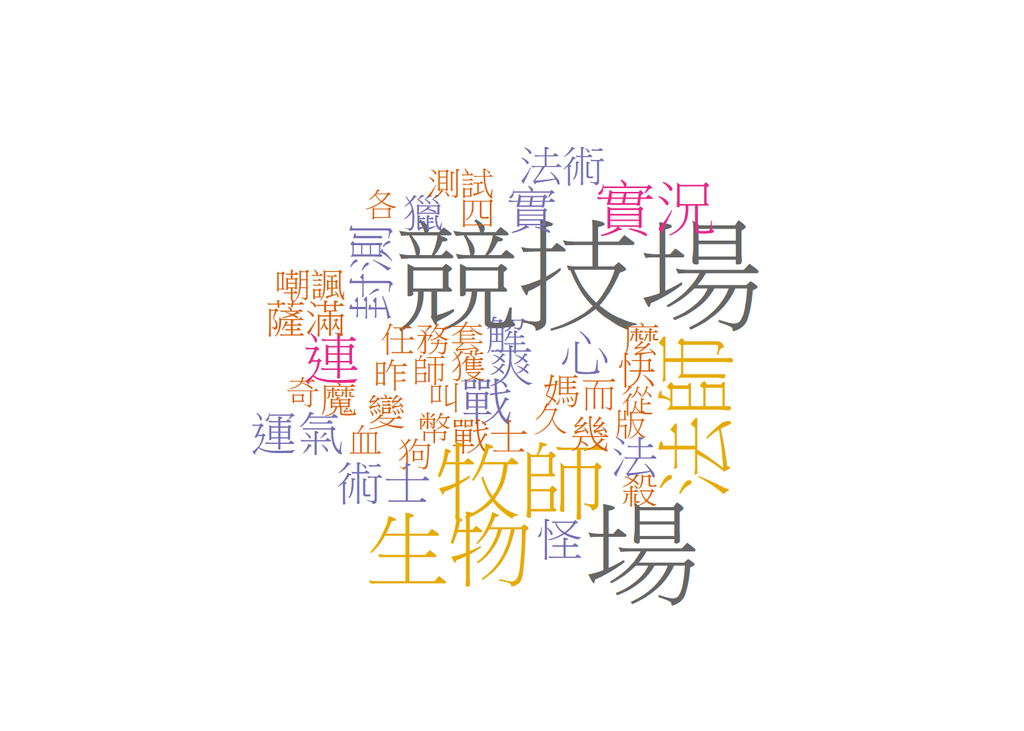

```r
wordcloud(freqFrame$Var1,freqFrame$Freq,
          scale=c(5,0.5),min.freq=50,max.words=150,
          random.order=TRUE, random.color=FALSE,
          rot.per=.1, colors=brewer.pal(8, "Dark2"),
          ordered.colors=FALSE,use.r.layout=FALSE,
          fixed.asp=TRUE)
```

### 文字雲分析

我以自身遊戲體驗和文字雲的發現，得到以下幾點論點：

1. 從最大的「競技場」樣式來看，可以看出競技場模式在爐石中的地位，因為爐石只要一個版本沒有跟上，基本上就組不了新牌打標 準模式，所以有些玩家只打競技場，競技場只需要有觀念和牌技，不需要自己養成牌組。
2. 生物、牧師、法師是第三大的字樣，就最近幾個版本的現象來看也十分合理。法師一直都是熱門牌組；牧師過去幾個版本一直都有 非常強勢的牌組；生物在爐石中直接影響場面，可以說是贏牌最重要的元素。
3. 接下來少數在文字雲中的職業和牌組是戰士、術士、薩滿還有嘲諷。戰士這季可以組嘲諷戰；術士出現頻率很高八成是因為上一個 版本術士可以說是最強牌組;薩滿在新版本中有偶數薩和嘯斗薩兩套新牌可以玩；嘲諷是一個固定戰術的牌組，目前版本有嘲諷戰和嘲諷德魯伊，都頗強勢。

若沒玩過爐石的人，這裡有官網的 [介紹](https://playhearthstone.com/zh-tw/game-guide)。